# Music EDX Capstone Project Report

**Are tempo, valence, duration, danceability, and energy potential good predictors?**

The distributions visualisations previously performed indicate that energy and danceability do not has distinct distribution among the classes, therefore no further review of these distributions was considered. However, i studied the relationship of these variables with other variables of interest. Previously, I have also noted that energy and loudness are correlated.

- songs by tempo and class:

```r
# considering tempo interquartile by classes

training %>% filter(Is_hit== "No") %>% select(tempo) %>% summary(.)
```

```
##      tempo
##  Min.   : 61.31
##  1st Qu.:130.01
##  Median :149.98
##  Mean   :152.46
##  3rd Qu.:174.99
##  Max.   :220.29
```

```r
training %>% filter(Is_hit== "Yes") %>% select(tempo) %>% summary(.)
```

```
##      tempo
##  Min.   :  0.00
##  1st Qu.: 99.58
##  Median :119.20
##  Mean   :120.59
##  3rd Qu.:136.80
##  Max.   :216.20
```

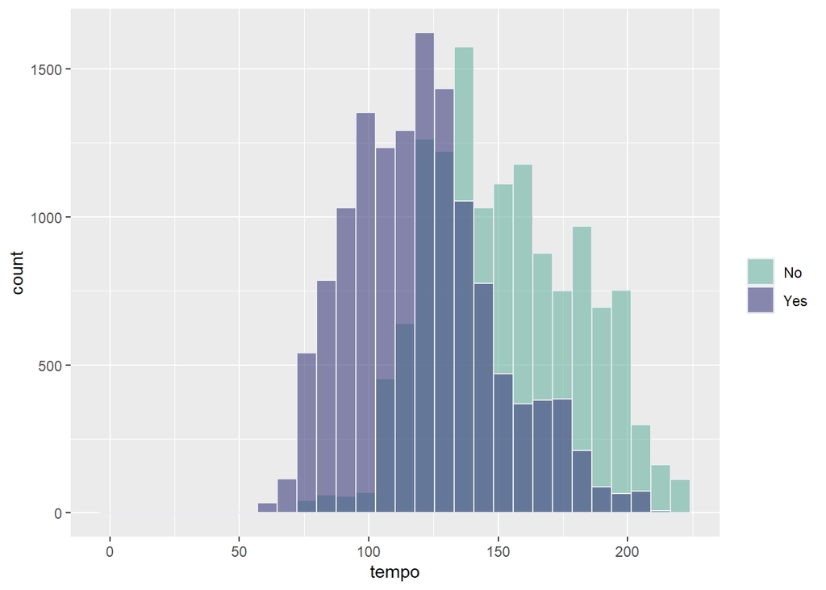

```r
#tempo distribution by classes
training %>%
  ggplot( aes(x=tempo, fill=Is_hit)) +
  geom_histogram( color="#e9ecef", alpha=0.6, position = 'identity', bins = 30) +
  scale_fill_manual(values=c("#69b3a2", "#404080")) +
  labs(fill="")
```

- songs by valence and class:

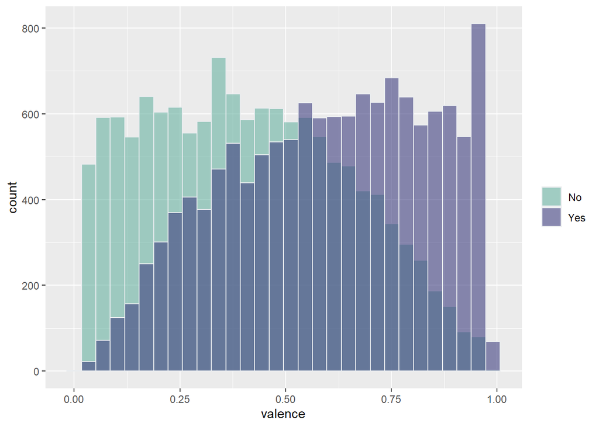

```r
#valence distribution by classes
training %>%
  ggplot( aes(x=valence, fill=Is_hit)) +
  geom_histogram( color="#e9ecef", alpha=0.6, position = 'identity', bins = 30) +
  scale_fill_manual(values=c("#69b3a2", "#404080")) +
    labs(fill="")
```

- songs by duration and class:

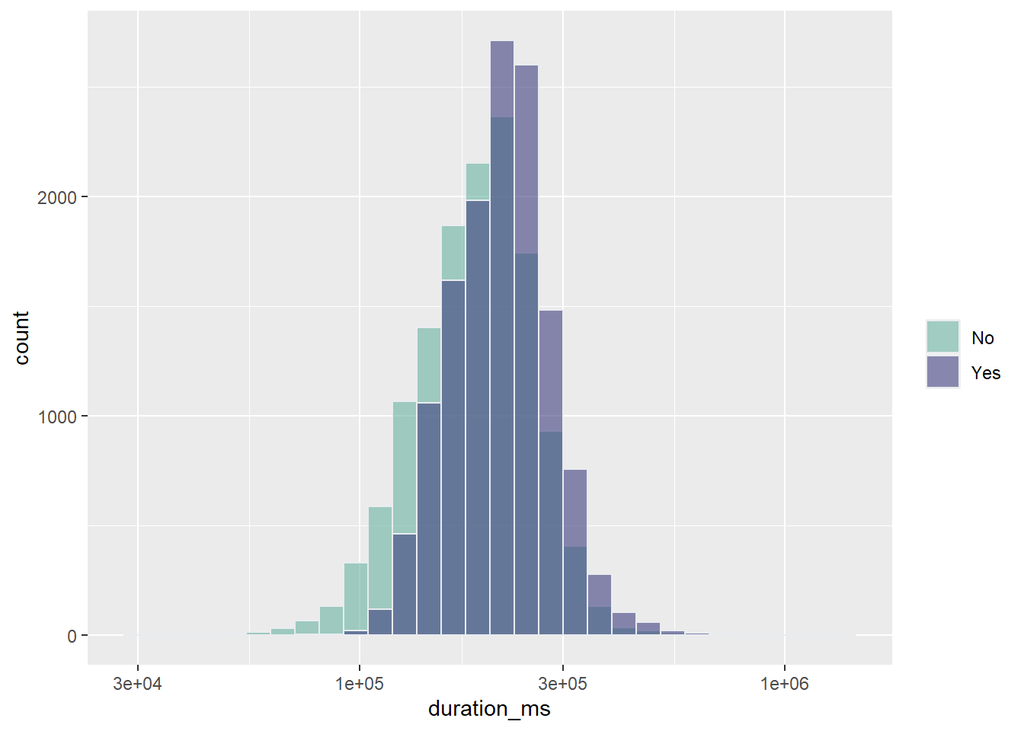

```r
#considering the distribution of duration
#histogram by class
training %>%
  ggplot( aes(x=duration_ms, fill=Is_hit)) +
  geom_histogram( color="#e9ecef", alpha=0.6, position = 'identity', bins = 30) +
  scale_fill_manual(values=c("#69b3a2", "#404080")) +
  labs(fill="") +
  scale_x_log10()
```